# Practical MAchine Learning Assignment

Antoine Mertz

3/8/2018

We load the libraries we will need:

```r
library(dplyr)
library(caret)
```

```r
library(corrplot)
library(tictoc)
```

# Background

Using devices such as Jawbone Up, Nike FuelBand, and Fitbit it is now possible to collect a large amount of data about personal activity relatively inexpensively. These type of devices are part of the quantified self movement – a group of enthusiasts who take measurements about themselves regularly to improve their health, to find patterns in their behavior, or because they are tech geeks. One thing that people regularly do is quantify how much of a particular activity they do, but they rarely quantify how well they do it. In this project, your goal will be to use data from accelerometers on the belt, forearm, arm, and dumbell of 6 participants. They were asked to perform barbell lifts correctly and incorrectly in 5 different ways. More information is available from the website here: http://web.archive.org/web/20161224072740/http:/groupware.les.inf.puc-rio.br/har (see the section on the Weight Lifting Exercise Dataset).

The goal of the project is to predict the manner in which they did the exercise. This is the `classe` variable in the data set.

# Data preprocessing

First, we load the train and test data

```r
train <- read.csv("~/Documents/perso/Perso/Coursera/Data Science - John Hopkins/datasciencecoursera/practical-machine-learning/project/pml-training.csv")
test <- read.csv("~/Documents/perso/Perso/Coursera/Data Science - John Hopkins/datasciencecoursera/practical-machine-learning/project/pml-testing.csv")
```

We can have a look on the data (there is too many columns, and because this is not the goal of the project, we can’t display the complete header and the structure of the data):

```r
str(train, list.len=15)
```

```
## 'data.frame':    19622 obs. of  160 variables:
##  $ X                       : int  1 2 3 4 5 6 7 8 9 10 ...
##  $ user_name               : Factor w/ 6 levels "adelmo","carlitos",..: 2 2 2 2 2 2 2 2 2 2 ...
##  $ raw_timestamp_part_1    : int  1323084231 1323084231 1323084231 1323084232 1323084232 1323084232 1323084232 1323084232 1323084232 1323084232 ...
##  $ raw_timestamp_part_2    : int  788290 808298 820366 120339 196328 304277 368296 440390 484323 484434 ...
##  $ cvtd_timestamp          : Factor w/ 20 levels "02/12/2011 13:32",..: 9 9 9 9 9 9 9 9 9 9 ...
##  $ new_window              : Factor w/ 2 levels "no","yes": 1 1 1 1 1 1 1 1 1 1 ...
##  $ num_window              : int  11 11 11 12 12 12 12 12 12 12 ...
##  $ roll_belt               : num  1.41 1.41 1.42 1.48 1.48 1.45 1.42 1.42 1.43 1.45 ...
##  $ pitch_belt              : num  8.07 8.07 8.07 8.05 8.07 8.06 8.09 8.13 8.16 8.17 ...
##  $ yaw_belt                : num  -94.4 -94.4 -94.4 -94.4 -94.4 -94.4 -94.4 -94.4 -94.4 -94.4 ...
##  $ total_accel_belt        : int  3 3 3 3 3 3 3 3 3 3 ...
##  $ kurtosis_roll_belt      : Factor w/ 397 levels "","-0.016850",..: 1 1 1 1 1 1 1 1 1 1 ...
##  $ kurtosis_picth_belt     : Factor w/ 317 levels "","-0.021887",..: 1 1 1 1 1 1 1 1 1 1 ...
##  $ kurtosis_yaw_belt       : Factor w/ 2 levels "","#DIV/0!": 1 1 1 1 1 1 1 1 1 1 ...
##  $ skewness_roll_belt      : Factor w/ 395 levels "","-0.003095",..: 1 1 1 1 1 1 1 1 1 1 ...
##   [list output truncated]
```

Then we split the train data in two data sets: one will be used for training and the other one will be used to validate the model with data unseen during training and with this second one we will be able to estimate the error out-of-sample (and so estimate the error on test data submitted on Coursera).

```r
set.seed(123)
inTrain  <- createDataPartition(train$classe, p=0.7, list=FALSE)
validate <- train[-inTrain, ]
train <- train[inTrain, ]
```

We have now three data sets: training, validating and testing:

```r
print(dim(train))
```

```
## [1] 13737   160
```

```r
print(dim(validate))
```

```
## [1] 5885  160
```

```r
print(dim(test))
```

```
## [1]  20 160
```

Then we treat the data to have a cleaner data set removing variables with near zero variance and then with a ratio of missing values higher than 30%. We do this on the train data to have a non bias estimator on the validate and test data. (After checking, if all variables removed with a `NA` ratio higher than 30%, have at least 97.8% of `NA` so we can clearly remove these variables without question or doubt).

```r
# Zero variance variables
NZV <- nearZeroVar(train)
train <- train[, -NZV]
validate <- validate[, -NZV]
test <- test[, -NZV]

# Variable with too many missing values
AllNA <- sapply(train, function(x) mean(is.na(x))) > 0.3
train <- train[, AllNA == FALSE]
validate <- validate[, AllNA == FALSE]
test <- test[, AllNA == FALSE]
```

```r
print(dim(train))
```

```
## [1] 13737    59
```

```r
print(dim(validate))
```

```
## [1] 5885   59
```

```r
print(dim(test))
```

```
## [1] 20 59
```

Then we removed “`id`” variables (not usefull for the model like name for example).

```r
train <- train %>%
  select(-c(X, user_name, raw_timestamp_part_1, raw_timestamp_part_2, cvtd_timestamp))

test <- test %>%
  select(-c(X, user_name, raw_timestamp_part_1, raw_timestamp_part_2, cvtd_timestamp))

validate <- validate %>%
  select(-c(X, user_name, raw_timestamp_part_1, raw_timestamp_part_2, cvtd_timestamp))
```

# Exploratory Data Analysis (EDA)

To not have a too long report and because it is not the goal of the assignment, we will have a limited EDA. We can imagine looking boxplot for each variable, perform ANOVA, etc… But we will just have a look on correlation.

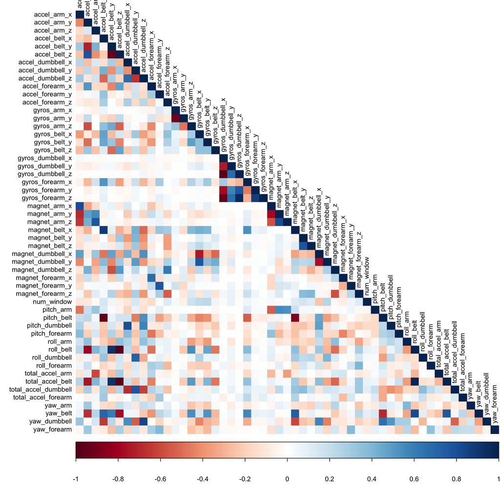

```r
corMatrix <- cor(subset(train, select = -c(classe)))
corrplot(corMatrix, order = "alphabet", method = "color", type = "lower", tl.cex = 0.8, tl.col = rgb(0, 0, 0))
```

Some variables are highly correlated (positive or negative). But to test if they have an important impact on the model we can test to perform PCA before modelization (as a `preProcess` argument in the `train` function of `caret`). But we will do that if performance is not well on validate data (compare to what we obtain on train set).

# `class` variable prediction

For training the data, we use cross-validation on the training data. We use 5 cross-validation folders that and each folder will have almost 2750 observations that is I think sufficient to avoid over fitting on training data and we will validate the model on validate data.

For a first try, we use random forest, then we will try SVM as classifier, and finally we will test GBM classifier.

## Random Forest

```r
set.seed(1234)
controlModel <- trainControl(method="cv", number=5, verboseIter=FALSE)

# Train
tic("Training Random Forest... ")
rf <- train(classe ~ ., data = train, method = "rf", trControl=controlModel)
toc()
```

```
## Training Random Forest... : 513.662 sec elapsed
```

```r
# Performance on the training data
train.rf <- predict(rf, subset(train, select = -c(classe)))
confusionMatrix(train.rf, train$classe)
```

```
## Confusion Matrix and Statistics
##
##           Reference
## Prediction    A    B    C    D    E
##          A 3906    0    0    0    0
##          B    0 2658    0    0    0
##          C    0    0 2396    0    0
##          D    0    0    0 2252    0
##          E    0    0    0    0 2525
##
## Overall Statistics
##
##                Accuracy : 1
##                  95% CI : (0.9997, 1)
##     No Information Rate : 0.2843
##     P-Value [Acc > NIR] : < 2.2e-16
##
##                   Kappa : 1
##  Mcnemar's Test P-Value : NA
##
## Statistics by Class:
##
##                      Class: A Class: B Class: C Class: D Class: E
## Sensitivity            1.0000   1.0000   1.0000   1.0000   1.0000
## Specificity            1.0000   1.0000   1.0000   1.0000   1.0000
## Pos Pred Value         1.0000   1.0000   1.0000   1.0000   1.0000
## Neg Pred Value         1.0000   1.0000   1.0000   1.0000   1.0000
## Prevalence             0.2843   0.1935   0.1744   0.1639   0.1838
## Detection Rate         0.2843   0.1935   0.1744   0.1639   0.1838
## Detection Prevalence   0.2843   0.1935   0.1744   0.1639   0.1838
## Balanced Accuracy      1.0000   1.0000   1.0000   1.0000   1.0000
```

Accuracy is 100% so maybe we have over fitted on the training set. But seems that correlated variables are not a huge problem for what we are trying to classify. Let have a look on the validate set for verifying that we don’t over fitting.

```r
# Validation
validate.rf <- predict(rf, subset(validate, select = -c(classe)))
confusionMatrix(validate.rf, validate$classe)
```

```
## Confusion Matrix and Statistics
##
##           Reference
## Prediction    A    B    C    D    E
##          A 1674    4    0    0    0
##          B    0 1135    4    0    0
##          C    0    0 1022    5    0
##          D    0    0    0  958    0
##          E    0    0    0    1 1082
##
## Overall Statistics
##
##                Accuracy : 0.9976
##                  95% CI : (0.996, 0.9987)
##     No Information Rate : 0.2845
##     P-Value [Acc > NIR] : < 2.2e-16
##
##                   Kappa : 0.997
##  Mcnemar's Test P-Value : NA
##
## Statistics by Class:
##
##                      Class: A Class: B Class: C Class: D Class: E
## Sensitivity            1.0000   0.9965   0.9961   0.9938   1.0000
## Specificity            0.9991   0.9992   0.9990   1.0000   0.9998
## Pos Pred Value         0.9976   0.9965   0.9951   1.0000   0.9991
## Neg Pred Value         1.0000   0.9992   0.9992   0.9988   1.0000
## Prevalence             0.2845   0.1935   0.1743   0.1638   0.1839
## Detection Rate         0.2845   0.1929   0.1737   0.1628   0.1839
## Detection Prevalence   0.2851   0.1935   0.1745   0.1628   0.1840
## Balanced Accuracy      0.9995   0.9978   0.9975   0.9969   0.9999
```

Again accuracy is high (higher than 99%). Performance is not degrated so we can consider that we don’t over fit on the train data. If the model over fitted on the train data, the performance on unseen data (like validate set) would be much lower than what the model produce. And performance on validate set also confirm that correlated data are not a big deal for random forest model on this problem. So we don’t need to test with PCA pre-processing.

Now, we can calculate our predictions for the submission with this model.

```r
test.rf <- predict(rf, subset(test, select = -c(problem_id)))
```

## SVM

As a second model to test other things that random forest.

```r
set.seed(12345)
controlModel <- trainControl(method="cv", number=5, verboseIter=FALSE)

# Train
tic("Training SVM... ")
svm <- train(classe ~ ., data = train, method = "svmRadial", trControl=controlModel)
toc()
```

```
## Training SVM... : 336.104 sec elapsed
```

```r
# Performance on the training data
train.svm <- predict(svm, subset(train, select = -c(classe)))
confusionMatrix(train.svm, train$classe)
```

```
## Confusion Matrix and Statistics
##
##           Reference
## Prediction    A    B    C    D    E
##          A 3853  193    8    6    2
##          B   10 2367   82    4    6
##          C   41   83 2271  238   52
##          D    1    4   31 2003   78
##          E    1   11    4    1 2387
##
## Overall Statistics
##
##                Accuracy : 0.9377
##                  95% CI : (0.9335, 0.9417)
##     No Information Rate : 0.2843
##     P-Value [Acc > NIR] : < 2.2e-16
##
##                   Kappa : 0.9211
##  Mcnemar's Test P-Value : < 2.2e-16
##
## Statistics by Class:
##
##                      Class: A Class: B Class: C Class: D Class: E
## Sensitivity            0.9864   0.8905   0.9478   0.8894   0.9453
## Specificity            0.9787   0.9908   0.9635   0.9901   0.9985
## Pos Pred Value         0.9485   0.9587   0.8458   0.9462   0.9929
## Neg Pred Value         0.9945   0.9742   0.9887   0.9786   0.9878
## Prevalence             0.2843   0.1935   0.1744   0.1639   0.1838
## Detection Rate         0.2805   0.1723   0.1653   0.1458   0.1738
## Detection Prevalence   0.2957   0.1797   0.1955   0.1541   0.1750
## Balanced Accuracy      0.9826   0.9407   0.9557   0.9398   0.9719
```

Again accuracy is high (93.8%) but lower than with random forests. But training time is lower with SVM than with Random Forest so maybe for production model, a lower time of training can be interesting.

```r
# Validation
validate.svm <- predict(svm, subset(validate, select = -c(classe)))
confusionMatrix(validate.svm, validate$classe)
```

```
## Confusion Matrix and Statistics
##
##           Reference
## Prediction    A    B    C    D    E
##          A 1654   92    3    2    1
##          B    1 1009   52    4    6
##          C   18   33  958  106   19
##          D    1    2   13  851   41
##          E    0    3    0    1 1015
##
## Overall Statistics
##
##                Accuracy : 0.9324
##                  95% CI : (0.9257, 0.9387)
##     No Information Rate : 0.2845
##     P-Value [Acc > NIR] : < 2.2e-16
##
##                   Kappa : 0.9143
##  Mcnemar's Test P-Value : < 2.2e-16
##
## Statistics by Class:
##
##                      Class: A Class: B Class: C Class: D Class: E
## Sensitivity            0.9881   0.8859   0.9337   0.8828   0.9381
## Specificity            0.9767   0.9867   0.9638   0.9884   0.9992
## Pos Pred Value         0.9441   0.9412   0.8448   0.9372   0.9961
## Neg Pred Value         0.9952   0.9730   0.9857   0.9773   0.9862
## Prevalence             0.2845   0.1935   0.1743   0.1638   0.1839
## Detection Rate         0.2811   0.1715   0.1628   0.1446   0.1725
## Detection Prevalence   0.2977   0.1822   0.1927   0.1543   0.1732
## Balanced Accuracy      0.9824   0.9363   0.9488   0.9356   0.9686
```

Again, on validate set, accuracy is lower with SVM than with Random Forest. So, at this point of the report, Random Forest seems to be the better model.

Now, we can calculate our predictions for the submission with this model.

```r
test.svm <- predict(svm, subset(test, select = -c(problem_id)))
```

## GBM

As a final test we try GBM model.

```r
set.seed(123456)
controlModel <- trainControl(method = "repeatedcv", number = 5, repeats = 1)

# Train
tic("Training GBM... ")
gbm <- train(classe ~ ., data = train, method = "gbm", trControl=controlModel, verbose = FALSE)
toc()
```

```
## Training GBM... : 213.949 sec elapsed
```

```r
# Performance on the training data
train.gbm <- predict(gbm, subset(train, select = -c(classe)))
confusionMatrix(train.gbm, train$classe)
```

```
## Confusion Matrix and Statistics
##
##           Reference
## Prediction    A    B    C    D    E
##          A 3905    9    0    2    0
##          B    1 2629    9    5    3
##          C    0   19 2382   15    2
##          D    0    1    4 2229   12
##          E    0    0    1    1 2508
##
## Overall Statistics
##
##                Accuracy : 0.9939
##                  95% CI : (0.9924, 0.9951)
##     No Information Rate : 0.2843
##     P-Value [Acc > NIR] : < 2.2e-16
##
##                   Kappa : 0.9923
##  Mcnemar's Test P-Value : NA
##
## Statistics by Class:
##
##                      Class: A Class: B Class: C Class: D Class: E
## Sensitivity            0.9997   0.9891   0.9942   0.9898   0.9933
## Specificity            0.9989   0.9984   0.9968   0.9985   0.9998
## Pos Pred Value         0.9972   0.9932   0.9851   0.9924   0.9992
## Neg Pred Value         0.9999   0.9974   0.9988   0.9980   0.9985
## Prevalence             0.2843   0.1935   0.1744   0.1639   0.1838
## Detection Rate         0.2843   0.1914   0.1734   0.1623   0.1826
## Detection Prevalence   0.2851   0.1927   0.1760   0.1635   0.1827
## Balanced Accuracy      0.9993   0.9937   0.9955   0.9942   0.9965
```

Accuracy on train set is higher than the one reaches by SVM model but lower than Random Forest one (that can only be equaled). GBM seems to be a great model to clasify our target. Let’s see if don’t over fit and estimate the out-sample error.

```r
# Validation
validate.gbm <- predict(gbm, subset(validate, select = -c(classe)))
confusionMatrix(validate.gbm, validate$classe)
```

```
## Confusion Matrix and Statistics
##
##           Reference
## Prediction    A    B    C    D    E
##          A 1671    9    0    0    1
##          B    3 1117    9    3    1
##          C    0   11 1014   15    4
##          D    0    2    2  946    6
##          E    0    0    1    0 1070
##
## Overall Statistics
##
##                Accuracy : 0.9886
##                  95% CI : (0.9856, 0.9912)
##     No Information Rate : 0.2845
##     P-Value [Acc > NIR] : < 2.2e-16
##
##                   Kappa : 0.9856
##  Mcnemar's Test P-Value : NA
##
## Statistics by Class:
##
##                      Class: A Class: B Class: C Class: D Class: E
## Sensitivity            0.9982   0.9807   0.9883   0.9813   0.9889
## Specificity            0.9976   0.9966   0.9938   0.9980   0.9998
## Pos Pred Value         0.9941   0.9859   0.9713   0.9895   0.9991
## Neg Pred Value         0.9993   0.9954   0.9975   0.9963   0.9975
## Prevalence             0.2845   0.1935   0.1743   0.1638   0.1839
## Detection Rate         0.2839   0.1898   0.1723   0.1607   0.1818
## Detection Prevalence   0.2856   0.1925   0.1774   0.1624   0.1820
## Balanced Accuracy      0.9979   0.9887   0.9911   0.9896   0.9944
```

Accuracy still very good. GBM is a good model for our objective and is faster to train than Random Forest.

Now, we can calculate our predictions for the submission with this model.

```r
test.gbm <- predict(gbm, subset(test, select = -c(problem_id)))
```

# Conclusion

The accuracy of the 3 classifying methods presented above are:

Random Forest : 0.9976 SVM : 0.9324 GBM : 0.9886

Random Forest seems to be the best model we can easily build. With hyper parameter tuning and maybe other algorithms we will be able to improve accuracy. But accuracy is almost equals to 1. So this model can be sufficient. With this conclusion, Random Forest model will be applied to predict the 20 quiz results (testing dataset).